# Life cycle assessment (and environmental footprint) to support food labelling schemes: an overview of current proposals and future directions - ScienceDirect

- [View **PDF**](https://www.sciencedirect.com/science/article/pii/S2666789425000807/pdfft?md5=700fb0a66c4b3a94f557c2f96308b67c&pid=1-s2.0-S2666789425000807-main.pdf)

## [Cleaner Environmental Systems](https://www.sciencedirect.com/journal/cleaner-environmental-systems)

[Volume 19](https://www.sciencedirect.com/journal/cleaner-environmental-systems/vol/19/suppl/C), December 2025, 100334

# Life cycle assessment (and environmental footprint) to support food labelling schemes: an overview of current proposals and future directions

https://doi.org/10.1016/j.cesys.2025.100334[Get rights and content](https://s100.copyright.com/AppDispatchServlet?publisherName=ELS&contentID=S2666789425000807&orderBeanReset=true)

Under a Creative Commons [license](http://creativecommons.org/licenses/by/4.0/)

Open access

## Abstract

Sustainability labelling gained prominence in food policy discourse in recent years, particularly in Europe, although its effectiveness in influencing consumer behaviour remains uncertain. This work explores selected sustainability food labels in the EU, reviewing sustainability indicators and the underlying life cycle assessment (LCA) methodologies. It addresses methodological approaches, and how they apply LCA with reference to the Product Environmental Footprint (PEF) method recommended by the European Commission. Four labels were identified from a comprehensive product database, focusing on labels applying LCA and quantifying multiple impacts, while an additional one was identified from the current EU panorama. An evaluation framework was developed on the relevant methodological aspects, encompassing governance, transparency, and clarity. Interviews with label developers complemented the analysis, along with a review of criticisms of LCA and PEF for labelling purposes. Four are scoring labels providing graded and colour-coded visuals, while one is still under development. Methodological adaptations to the PEF were common, and non-LCA sustainability assessments accounted for aspects such as farming management, social issues, and biodiversity. Labels varied in transparency, stakeholder involvement, and clarity. Criticisms of LCA include its reductionist approach, data gaps, and lack of robust methodologies for assessing biodiversity. While sustainability labelling is important to guide sustainable choices, labels need to be part of a broader policy mix and should be underpinned by clear goals and robust methodologies. This analysis will help to develop evidence-based policy instruments for sustainable consumption and set the basis for a harmonized labelling system.

## Keywords

Food labelling

Sustainability label

Environmental footprint

Life cycle assessment

Green claims

Food policy

## 1. Introduction

Global food systems are one the major contributors to the triple planetary crisis—climate change, biodiversity loss, and pollution (Hellweg et al., 2023). They account for a third of anthropogenic greenhouse gas emissions (Crippa et al., 2021) or around half of EU Consumption Footprints (Sala et al., 2023). Food systems are central to achieving global sustainability and are connected to several Sustainable Development Goals (Borchardt et al., 2024; United Nations, 2015). Sustainable food systems are pivotal in tackling the interconnected challenges of planetary and human health, including those posed by climate change and malnutrition (Turkie, 2022). To address these deep challenges, a transition towards sustainable food systems is imperative, and a central part of this transition is represented by widespread dietary change towards sustainable food consumption patterns (Laine et al., 2021). Changes in consumer choices can be nudged through information-based policies such as sustainability labelling (Cook et al., 2023; Potter et al., 2021). Demand-side strategies that guide consumer choices can promote the dietary shift by encouraging the purchase of different product groups (plant-based products vs. animal-based ones), and on selecting more sustainable options within the same product group. Increasing the demand for sustainable options can promote a change in production patterns through a catalyst effect (Cook et al., 2023). However, the effectiveness of information-based policies such as sustainability labelling for food products is debated (SAPEA, 2023) and should be embedded in a coherent policy mix geared to promoting sustainable consumption patterns, including education, marketing regulations and taxes (Springmann, 2024).

Recognising this potential, the European Commission (EC) highlighted the importance of sustainable labelling within its Farm to Fork Strategy (EC, 2020), aiming to enhance the overall sustainability of the EU's food systems. In the Strategic Dialogue on the Future of Agriculture (EC, 2024) and the Vision for Agriculture and Food (EC, 2025), sustainable labels are recognised as a powerful tool to support consumers to take sustainable decisions. However, recent studies have shown the rapid proliferation of different sustainability labelling schemes (Sanye Mengual et al., 2024; Nes et al., 2024) which risks leading to confusion and mistrust in consumers and potential greenwashing (Brown et al., 2020). Moreover, the presence of multiple types of information regarding health and nutrition on food products was not associated with a higher value of healthy food by consumers (Barreiro-Hurle et al., 2010; Grunert et al., 2014), and as a recent study shows 25 % of explicit environmental claims in food products in the EU market were potentially misleading (EC, 2020). Recent legislative initiatives, such as the proposal for the Green Claims Directive (EC, 2023), suggest that harmonizing sustainability information to consumers could be necessary to avoid greenwashing and eventually promote sustainable consumption.

Proposing a harmonised sustainability label would require defining its scope and the methodology used to support a product's sustainability claims. Main challenges towards this harmonisation include inconsistent methodologies, limited comparability across categories, and a focus on environmental rather than social impacts (Cicek et al., 2024). With environmental sustainability being a core element in the transition to a sustainable food system, proposals in the market and the literature have pointed towards life cycle assessment (LCA) as guiding cornerstone method to quantify the environmental information of food products. LCA (ISO, 2006a, ISO, 2006b) is being used as a methodological approach to provide a harmonised calculation of impacts to underpin labels. Notwithstanding its standardisation, LCA allows for methodological choices that can lead to diverging results. As a result, the EU followed a multi-stakeholder process resulting in the recommended Product Environmental Footprint (PEF) method (European Commission, 2021a), a LCA method which provides strict guidance on the application of LCA to quantify the impacts of a product. This method aims to ensure the robustness and comparability of results with the goal of enhancing consumer trust and avoiding greenwashing practices. Both LCA and the PEF have been taken as references for some of the labels being proposed in the market leading to different approaches and methods coexisting on the market.

This **paper critically reviews** food sustainability labelling initiatives which are using LCA, and specifically the PEF, as blueprints. The analysis's scope was limited to labels addressing multiple indicators of environmental sustainability (i.e. not focusing only on one impact such as carbon labelling). The analysis extrapolates the methodological propositions made by the different labels, together with other details about the label development, such as stakeholders involved, objectives of the labels and governance structures. The outcomes of this analysis give novel insights into the development of demand-side policies, such as sustainability labelling. The discussion points to the inherent complexity of framing sustainability in food systems, as well as at the limitations of defining robust quantitative indicators to support policy development.

## 2. Materials and methods

The analysis of the selected sustainability labels focussed on the methodology supporting the sustainability claims. The aim of this deep dive is to understand how LCA/PEF is currently applied by sustainability labelling, and thus how evidence-based policy instruments can be developed to effectively steer towards sustainable consumption. The labels were analysed with the support of an evaluation framework, which systematised the information concerning the general aspects of the labelling schemes (including governance, transparency, reliability, and clarity) and the methodological propositions made by the label developers in comparison with the PEF method. The analysis was qualitative and used publicly available documentation (including scientific and grey literature), supported by interviews and exchanges with label developers. Details on the evaluation framework and the interview questions can be found in the SM1.

### 2.1. Identification of existing scoring labels using LCA

The inclusion criteria for the labels to be considered in this study were (a) a business to consumer type of label, (b) covering multiple sustainability indicators through LCA methodologies (i.e. these covering more than one environmental category (e.g. climate change and water use), and possibly including other methods to assess the impact in other sustainability aspects such as animal welfare or impacts of different farming practices, and (c) providing the necessary level of transparency in their documentation to allow for its review (i.e. public and accessible information about the methods used is available). An extensive food sustainability label identification exercise was conducted in a separate exercise (Sanye Mengual et al., 2024) and was the starting point for this work. This exercise relied on the Mintel's Global New Products Database (GNPD) to search for existing sustainability-related logos present in packaged food products. The searched focused on all food and drinks and the EU market (except Cyprus, Malta and Luxembourg – which are not covered in Mintel). The product claims classification related to environmental and social positive impacts were chosen to define the scope of ‘sustainability-related logo’. Out of the more than 200 food sustainability labels identified (Sanye Mengual et al., 2024), four scoring labels were found to meet the inclusion criteria for the present study. The selection was complemented by an additional scheme under development by the French government. The latter was included in the analysis as the only known example of a government-led initiative in the EU complying with the inclusion criteria.

### 2.2. Evaluation framework

The general aspects of the labelling schemes, including governance, reliability, clarity, transparency, and monitoring built on a framework previously developed by the European Commission – Joint Research Centre (EC-JRC) and corroborated in a large-scale analysis of food labels (Sanye Mengual et al., 2024). *Governance* indicates the main stakeholder promoting the scheme. *Reliability* covers the monitoring and transparency of claims, giving quantitative and qualitative information that guarantees data and assumptions are accurate, consistent, and scientifically based. *Clarity* is the degree of effectiveness of visual communication of environmental information, as indicated by key literature. An overall score, derived from the points obtained in these criteria, is provided according to four ranks (‘very good’, ‘good’, ‘fair’, or ‘poor’) for clarity and reliability. The rank is evaluated by aggregating scores of a set of individually assessed sub-criteria, as detailed in SM1.1 (clarity) and SM1.2 (reliability). In terms of *transparency*, i.e. access to the underpinning documentation, all labels provide documentation on the methodologies developed. However, the extent of detail and availability of information varies. *Monitoring* was also evaluated to identify the presence of any system, such as a protocol, to ensure the compliance of the product with the standards defined under each scheme.

In addition to these general aspects, the evaluation framework covers the main parts of an LCA study: Goal and scope, Life Cycle Inventory (LCI), Life Cycle Impact Assessment (LCIA), and Interpretation, including normalisation and weighting. The comparison with PEF method followed the requirements set out in the recommendation (EC, 2021) in terms of inventory database used, data quality, and impact assessment methods. When available, information on the translation of the LCA results into a score or visual labels were also analysed. Methodological propositions concerning the quantification of non-LCA sustainability aspects are also made by a subset of labels. The extraction of the information supporting these propositions was useful to understand for which food system domains methodological advancements are necessary, or which aspects are not currently included in LCA's framework.

Given the rapid development of the sustainability labelling landscape, some interviews were conducted with the label developers to ensure that the most up-to-date information was used for the analysis, such as on the commercial uptake of each scheme.

### 2.3. Identification of PEF criticisms

The label analysis was complemented by a narrative review of grey and scientific literature addressing key challenges related to LCA and PEF, especially in application to food products. The review included position papers from some organizations dealing with organic food products, researchers supporting the development of food labels using LCA methods, and other documents shared by stakeholders to the PEF developers, properly listed in the references section. The EC recommends the use of Environmental Footprint methods to evaluate the impacts of products (under PEF) and organizations (under OEF) (EC, 2021). This review proved instrumental in framing the methodological proposals made by the label developers in a broader scientific discourse and in systematizing the gaps and criticalities of these methods.

## 3. Results

In this section, various food labelling schemes are presented, focusing on their Life Cycle Assessment (LCA) methodologies and on how they integrate non-LCA aspects to assess sustainability, and how the results are translated into graded labels and the potential for consumer confusion or understanding due to differing methodologies.

### 3.1. LCA-based food labels covering multiple sustainability aspects in the EU market

Five labelling schemes were included in the scope of this analysis, namely Ecoscore, Planet-score, Ecoimpact, Enviroscore, and the French Government Initiative (referred to as FGI in this study) (Table 1). The first four labelling schemes analysed were extracted from the mapping and are all scoring labels, providing information to consumers as a colour-graded visual score within the packaging of the food product evaluated. At the time of conclusion of this research (September 2024), the visual component of communication to consumers of FGI was unknown, thus preventing its classification as ‘scoring label’, as well as its implementation status.

Table 1. Overview of the schemes analysed: sustainability aspects covered, and stakeholder involved.

| Label | Pictogram | Sustainability dimension covered | Stakeholders promoting the initiative | Approach |
| --- | --- | --- | --- | --- |
| Ecoimpact |  | Environmental | Food businesses, NGO, data providers and developers, universities and research centres | The main objective is scaling up the provision of environmental information to consumers and ensure harmonization of the methodology used in the food industry. A second objective is to make the labell… |
| Ecoscore |  | Environmental, social (partly, only animal welfare, specific production management schemes) | NGOs, consumer information and consumer rights organizations | The environmental scoring label is meant to inform consumers on the environmental impact of a product or plate. |
| Enviroscore |  | Environmental | Research centre (Azti), university (KU Leuven) | Enviroscore is meant to enable consumers in comparing food products, and accompany food businesses in quantifying, evaluating and communicating environmental improvements. |
| FGI | Not available | Environmental | French government and environmental agency (ADEME), stakeholders, other policymakers also at EU level | The main objective is to operationalise what is foreseen by the Climate and Resilience Law of 2021, art. 2, which introduces the development of a environmental impacts display intended for consumer in… |
| Planet-score |  | Environmental, social (partly, only animal welfare) | NGOs, organic agriculture interest groups and research centre | The methodology developed by the Planet-score is designed as an instrument to make farming practices more visible, as improvements to farming management practices put in place by farmers should be mor… |

From a regulatory point of view, four of these labels are voluntary and proposed by a variety of food system stakeholders. The FGI, on the other hand, represents a particular case, being the pilot initiative started by the French Government following the ambition of the Climate and Resilience Law (Republique Française, 2021) of 2021, foreseeing environmental labelling for goods and services with textiles and foods indicated as pilot sectors. All five schemes are developed by multi-stakeholder partnerships between food businesses, research centres, data providers, and civil society organizations (Table 1). In particular, FGI followed a consultative process that emphasizes engagement and cooperation with a broad range of contributors.

The specific objectives of each label identified differ based on the stakeholders promoting them and are also mirrored in the methodological propositions and adjustments made.

#### 3.1.1. General aspects of analysed labels

According to the authors’ evaluation, three schemes rank as “fair” under the *reliability* criterion and two as “good”, based on the availability of information supporting the claims. Only one scheme (Planet-score) ranked very good regarding *clarity* as it proposes a visual scoring system which is explicit and quite easy to understand, while the other schemes were evaluated good or fair. Compared to the other labels, Planet Score was ranked better in the 7 sub-criteria – derived from milestone literature as detailed in SM1.1 (Stein and de Lima, 2021, UNEP, 2017, Perrin, 2021 ) – and was evaluated as a label providing clear information, covering multiple aspects and using pictograms for different elements of sustainability. In terms of *transparency*, all schemes offer documentation on their methodologies; however, the level of detail and accessibility of this information varies. EcoImpact (Earth Foundation, 2023), which is more commercially driven, protects parts of its methodology under intellectual property rights, specifically concerning the scoring system (i.e., how LCA results are translated into a graded score), as indicated in an interview with EcoImpact representatives. Planet-score documentation lacks a written systematization of the methodology due to its rapid and continuous operational changes, possibly leading to some discrepancies between practice and published guidance. Enviroscore is more transparent with its methodological proposals, which are detailed in a peer-reviewed scientific paper by Ramos et al. (2022). FGI is the most transparent among the analysed labels according to the evaluation framework, as all the developments are published in a public online dashboard.

In terms of *monitoring*, all the schemes appear to lack clear protocols for ensuring compliance. While Ecoscore has implemented a third-party audit for data received from food businesses, the specifics on this process are not publicly provided. Additionally, the labelling initiatives do not disclose plans for traceability systems within supply chain analyses, nor for data sharing related to LCI.

Based on information provided in the interviews with the developers, EcoImpact and Planet-score are more commercially advanced in terms of commercial use as both labels have been adopted by a wide variety of food producers and on many food products on the market. Enviroscore is still at the pilot scale and findings did not identified any commercial use. This could be caused by the resource intensiveness of its approach, which, being closer to the PEF, requires the collection of detailed primary data. FGI is currently under a methodological development stage, with an launch of uniform labelling for the textile sector in the fall of 2024, while, according to available documentation, for food there is an ongoing round of public consultations with stakeholders to validate the methodological choices (Republique Française, 2024). Ecoscore is only applied in France and has suspended its geographical expansion, according to the interview with the developers. One major limitation for commercial expansion lies in the use of Agribalyse (Asselin-Balençon et al., 2022) as the only source of the LCA score, which raised difficulties for the calculation of non-French products when appropriate proxies do not exist. Furthermore, its methodological developments were halted due to the ongoing development of the government-led initiative with label developers aiming to align with the national proposal.

Overall, these four labels fully developed are all associated with a graded scoring as visual information, helping consumers to intuitively link the graded logo to sustainability performance. Differences are found concerning the transparency of the methodologies used and the assumptions behind the different scoring options. These two approaches foresee the modification of the final LCA score through a reward and penalty system (known as Bonus/Malus), addressing aspects such as agricultural practices (organic) or animal welfare. None of the schemes provides detailed information about products via websites or digital means, which has often been suggested by certain food sector stakeholders (FoodDrink Europe, 2024). Further analysis concerned the reliability, clarity and transparency behind the five sustainability labelling schemes, as shown in Table 2.

Table 2. Reliability, clarity, and transparency of each scheme.

| Label | Reliability | Clarity | Transparency Access to documentation on methodology underpinning label | Transparency Underpinning data sources | Transparency Limits of claim/uncertainties clearly stated |
| --- | --- | --- | --- | --- | --- |
| Ecoimpact | Fair | Fair | yes | yes | no |
| Ecoscore | Fair | Fair | yes | yes | no |
| Enviroscore | Good | Good | yes | no | no |
| FGI | Good | NA | yes | yes | yes |
| Planet-score | Fair | Very Good | yes | yes | yes, but publication not available (only claim) |

### 3.2. LCA methodological aspects

All evaluated labelling schemes are based on LCA as defined by the scope of this research, and all refer to some extent to the PEF method (European Commission, 2021a). The degree to which the PEF was fully applied or just taken as a blueprint for further developments varies among the labels. EcoImpact and Enviroscore assert to be PEF compliant while providing some modifications to the methodology. FGI is proposing a method dubbed “PEF+”, hinting at the inclusion of additional elements in the product assessment (see Fig. 1 the system boundaries of each scheme analysed). Ecoscore and Plantescore use Agribalyse, which is also PEF based, albeit with some modifications. All labels apply slightly different mass-based functional units as reflected in SM2, covering prepared or consumed food. By using the common blueprint of the PEF for their development, the labels use a mass-based functional unit and cradle-to-grave system boundaries. Differences in the goal and scope concern the inclusion of food waste in the assessment, the modelling of the use phase (cooking and consuming food) and how composite products are modelled.

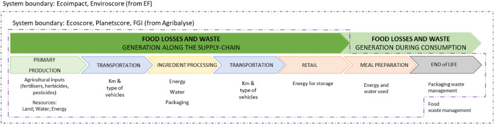

1. [Download: Download high-res image (484KB)](https://ars.els-cdn.com/content/image/1-s2.0-S2666789425000807-gr1_lrg.jpg)
2. [Download: Download full-size image](https://ars.els-cdn.com/content/image/1-s2.0-S2666789425000807-gr1.jpg)

Fig. 1. System boundaries in each scheme evaluated.

The life cycle inventory (LCI) data used by the labels mostly refers to the most commonly available commercial databases, such as ecoinvent, agrifootprint and Agribalyse, the latter especially in the French cases as it has been developed specifically to reflect French production. In terms of preference for primary data, the different labelling approaches diverge in their methodologies, with Ecoimpact providing a ranking system to choose appropriate data sources and Enviroscore clearly prioritizing primary data for each products. As food products are often composed by multiple ingredients, a key aspect of the label scoring concerns the modelling of composite products. Two labels provide recommendations in this respect (see Table 3 for further details).

Table 3. Life Cycle Inventory and Life Cycle Impact Assessment corrections proposed by EcoImpact, FGI, and Planet-score.

| Scheme | Affected stage | Aspect | Proposed change | Rationale | Supporting source |  |  |  |
| --- | --- | --- | --- | --- | --- | --- | --- | --- |
| EcoImpact | LCI | Allocation for dairy processing | Economic allocation | Discrepancy between feed PEFCR (economic) and dairy PEFCR (mass) | Dairy PEFCR |  |  |  |
|  |  | Allocation at crop cultivation for grape production (allocation of co-products: grape must and grape pomace) | Economic allocation | Discrepancy between wine PEFCR (mass) and crop PEFCR (economic) | Wine PEFCR |  |  |  |
|  |  | Allocation at food production for pasta | Economic allocation | Discrepancy between feed PEFCR (economic) and dairy PEFCR (mass) | Pasta and wine PEFCR |  |  |  |
| FGI | LCIA | Toxicity (cancer, non-cancer) | Deleted until there is a more robust and consolidated methodology | The EF is not satisfactory in the modelling of these impacts | NA |  |  |  |
|  |  |  |  |  | Internal testing on agribalyse data done by scheme’ developers showed “modelling inconsistencies”. |  |  |  |
|  |  | Freshwater ecotoxicity | Increase weighting to 21 %, similarly to climate change | French government do not support the “robustness factor” approach used in EF which leads to reduce strongly the weighting of ecotox indicator. The environmental concern is high regarding toxicity/pest… | NA It relies on documentation available about the extent of toxicity contamination and pesticide effect on global biodiversity loss. |  |  |  |
|  | LCI | Water Use | Modification of global water consumption flows to align with French water consumption | Inventories used, including Agribalyse, use global water flows. The water related impact of French products was overestimated. | NA |  |  |  |
| Planet-score | LCIA | Impact Category: Climate change (ME) | Corrected characterization factors for: N20 at field level, for biogenic methane and carbon storage. The approach currently adopted in the methodology is to achieve a weighted average between the two … | IPCC 2019 provides updated characterization factors; carbon storage in agricultural soils is useful for climate change mitigation (positive externality of agriculture). | (IPCC, 2019, Pellerin et al., 2019, IPCC, 2021) |  |  |  |
|  |  | Impact Category: Freshwater ecotoxicity (ME) | Pesticide emissions to different compartments of the environment (air, soil, water) are converted into impact for the freshwater, marine and terrestrial ecosystems using the USEtox_LC-Impact model, as… | LCA models pesticides only for the soil compartment. | (Planetscore, 2021) |  |  |  |
|  |  | Impact Category: Acidification (ME) | Correction for ammonia emissions | In husbandry systems where animals have access to pasture ammonia emissions due to manure are reduced of up to 70–90 %. Reducing the importance of ammonia emissions in animal rearing compared to EF3 | Planetscore (2021), citing: (CITEPA, 2013; Martin, E. and Mathias, 2013) |  |  |  |
|  |  | Impact Category: Terrestrial eutrophication (ME) |  |  |  |  |  |  |
|  |  | Impact Category: Particulate matter (ME) |  |  |  |  |  |  |
|  |  | Impact Category: Land use (ME) |  |  |  | Correct the land occupation inventories, by cancelling the impact of surfaces in permanent grasslands, a source of biodiversity | To limit the competition between feed and food. Permanent grasslands are best used as feed for herbivores. The flows from Agribalyse are corrected | (Knudsen et al., 2017; Ridoutt, B., & Garcia, 2020); |
|  |  | Human toxicity (ME) |  |  |  | Emissions to different compartments are converted in impacts with USEtox_LC-Impact (air, water, soil) and Dynamicrop for the plant compartment | Low carachterization of human toxicity –cancer; no take into account of cocktail effects, metabolites. | Cancer effects: IARC, US-EPA and EU. Cocktail effects: Medina-Pastor and Triacchini (2020) |
|  |  | Human Health (EP) | Proposed weighting 25 %Grouping MP: Human toxicity non-cancer effects; human toxicity cancer effects, particulate matter, Ionising radiation, photochemical ozone formation, ozone depletion | These aspects are a combination between the impact categories presented and the non-LCA methods applied. | Planetscore (2021) |  |  |  |
|  |  | Environmental Health and Biodiversity (EP) | Proposed weighting 49 % Grouping MP: Acidification, eutrophication (terrestrial, freshwater, marine), freshwater ecotoxicity, land use, water use |  |  |  |  |  |
|  |  | Climate (EP) | Proposed weighting 12 % Grouping MP: Climate change |  |  |  |  |  |
|  |  | Resources (EP) | Proposed weighting 12 % Grouping MP: resource use, minerals & metals, and fossils |  |  |  |  |  |

MD: Midpoint, ED: Endpoint.

The LCIA methods used by the labelling schemes vary, but each initiative claims to be based on the PEF. These adaptations range from minor adjustments, such as Enviroscore's use of its own normalisation factors, to more extensive modifications, like Planet-score's exclusion of certain impact categories and use of non-LCA methods. Ecoscore relies on the Agribalyse method with a penalties and reward system, without proposing any methodological modifications. FGI makes targeted changes to three impact categories, including toxicity and freshwater ecotoxicity, and introduces new weighting factors. Planet-score stands out with the most adaptations, namely excluding certain impact categories and introducing extensive modification to overcome LCA's shortcomings in modelling farming systems. Fig. 2 shows how labels deviate from EF LCIA, while Table 3 shows impact modelling modifications in the studied schemes.

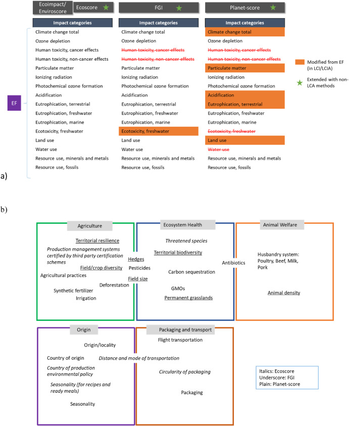

1. [Download: Download high-res image (1MB)](https://ars.els-cdn.com/content/image/1-s2.0-S2666789425000807-gr2_lrg.jpg)
2. [Download: Download full-size image](https://ars.els-cdn.com/content/image/1-s2.0-S2666789425000807-gr2.jpg)

Fig. 2. Impact Assessment Methods comparison: (a) Impact categories modifications from EF LCIA method, and (b) Non-LCA sustainability areas covered per scheme. a).

#### 3.2.1. Integration of different sustainability assessment methods

This analysis has revised the solutions proposed by Ecoscore, FGI, and Planet-score. SM4 details the main features of each bonus-malus system, while Fig. 2 provides an overview of the main topics covered by non-LCA methods per label. Ecoscore, FGI, and Planet-score each have distinct approaches to evaluating the sustainability of food products. Ecoscore addresses additional sustainability attributes beyond LCA, such as production management systems, transportation, and packaging circularity, and applies awards and penalties to the LCA score to create nuanced comparisons among products. Planet-score, on the other hand, proposes extensive adjustments to the LCA methodology, addressing a wide range of aspects including agricultural practices, pesticides, antibiotics, deforestation, and animal welfare, with a focus on promoting more sustainable and environmentally-friendly food production practices. The draft methodology from the FGI adds to the EF indicators 5 dimensions that were considered missing in EF by an “agro-biodiversity expert group”. The 5 extra-indicators contributing to the single score are: Hedges, Permanent grasslands benefit for biodiversity, Field size, Field/crop diversity, and Animal density at the “département (county) level”. Those elements are related to farming practices – inventory - more than ‘mid-point LCA indicators” and emphasise the environmental benefits of agro-ecological systems. Those dimensions could be connected to “Land Use” category in LCA framework.

#### 3.2.2. Interpreting the results into a graded label

Generally, the labelling schemes use as a basis LCA results in terms of a single score metric, as proposed by the EF. As a common aspect, the four schemes studied use classes corresponding to different letters to accompany the information provided to consumers. SM5 illustrates the overview of each method used to assign the colour grade and letters. Planet-score provides a further break-down of sustainability scores in three areas: pesticides, biodiversity and climate, in addition of an animal welfare score for animal products. The clarity with which the different classes are differentiated varies across the labelling schemes; this could inevitably lead to misunderstandings in consumers as similar colour shades and letters derived from different methodologies could be linked to different results. Presently, the PEF method does not foresee the visualization of a single score.

## 4. Discussion

This section discusses the main findings of the labels’ analysis in light of specific needs of a sustainability labelling scheme fostering the sustainability of food systems, as well as current open debates and limitations in LCA, particular elements related to the EF, and overall limitations of this study.

### 4.1. Labels as a leverage for food systems sustainability transition

Sustainable food labels, if well understood by consumers, could nudge them towards more sustainable food choices (Williams et al., 2023). However, the **existence of multiple labels** intended to reveal the environmental performance of products could potentially confuse consumers.

While a robust methodology and harmonise is essential to ensuring the efficacy of a sustainability label (Cicek et al., 2024), **reaching consumers through clear and understandable formats** and messages can determine its outcome. Scientific literature suggests that using a colour-code approach (e.g. traffic light to indicate different sustainability performance grades) is promising in business-to-consumer communication (Potter et al., 2021) and favours consumer choice and purchase of sustainable products, but more research is needed to understand what type of label would be best understood by consumers. Interviews with label developers hinted that using current PEF methodological recommendations would not capture differences in agricultural production methods within the same product category, resulting in all fruits and vegetables scoring favourably, regardless of production method, mean of transport, or packaging choice Ramos et al. (2022). This could suggest that while it might be effective in promoting a shift of diets, further guidance might be needed to mark the most sustainable options within food categories. The translation of PEF results into letters (A, B, C, D, E) or scores proves therefore to be challenging, and could lead to no differentiation on the market within the same product, thus possibly limiting the scope of sustainability labelling due to lack of incentives for food producers to use it.

The PEF was created to reliably compare products within the same category, for example: if comparing multiple types of pasta produced in different ways, the PEF can highlight differences in environmental impacts, but it will not enable a clear comparison of different sources of carbohydrates like rice or potatoes compared with pasta. The PEF includes two key steps before reaching the single score (which combines the 16 impact categories into a single score). These are normalisation and weighting. Normalisation involves comparing impact scores to a reference value, like the average impact of a person, product, or sector, to help stakeholders gauge their relative significance. It shows whether a product's impact is higher or lower than average in a specific category or region. Weighting assigns importance to different environmental impact categories based on criteria like value choices or policy priorities. After normalisation, scores are multiplied by weighting factors and summed to create the single score. This process highlights which products have a greater overall impact, but it is subjective, reflecting societal or stakeholder priorities. Conversely, most of the schemes analysed in this work are designed to summarise environmental impacts by converting them into a common scale and applying weights to reflect their relative importance. As Courtat et al. (2025) highlight the methods and thresholds applied in the development of scoring labels can lead to varying results for the same product.

The challenge of using LCA results as a basis for labelling lies in finding a balance between capturing the complexity of food products, and the diverse systems originating them, and providing clear and understandable information to consumers. In addition, operationalization and data requirements should not unnecessarily burden food producers.

Even if LCA has become a widespread methodology for food system analysis, it has been increasingly criticised by stakeholders and scientists alike for the overly **“reductionist” approach**, which could be overcome by integrating complementary perspectives and methods. By simplifying agricultural production to an inventory of raw materials and energy inputs, LCA would not account for the interdependencies and complexity of food systems, representing a major epistemological barrier (Cesiae, 2023). Indeed, food systems as socio-ecological systems feature complex interlinkages between technical and socio-economic activities (Guerrieri et al., 2025); the numerous stakeholders and possible framings of sustainability need to be taken into consideration in further discussions of what constitutes a sustainable food product. Additionally, the current gaps in LCA methodology in addressing agricultural practices and the provision of ecosystem services risks favouring intensive, eco-efficient, production systems rather than supporting the widespread transformation of agricultural production (Brimont and Saujot, 2021). Additionally, LCA focuses on the environmental dimension of sustainability, thereby excluding animal welfare or socioeconomic impacts nonetheless being fundamental in the assessment of food products. Indeed, some of the assessed schemes have included non-LCA aspects to address these issues. Sanye Mengual et al. (2024) showed that the assessment of decent work conditions is prioritised in available labels in the EU market while neglecting fair trade, community support, and gender equality aspects. In this context, a harmonised methodological approach could reduce these assessment inequalities, e.g. based on the Guidelines for Social Life Cycle Assessment of Products and Organizations (UNEP et al., 2020). Complementing LCA results with Social LCA (UNEP et al., 2020) could unearth social issues related to food production and consumption, possibly unveiling trade-offs between sustainability dimensions, as seen in an assessment of the social footprint of the EU food consumption (Mancini et al., 2023). Notwithstanding the potential of social LCA, this methodology is still not as advanced as environmental LCA and would require more time and research to be fully operational (Desiderio et al., 2022).

Furthermore, approaching the topic of food labelling from a merely methodological perspective and without incorporating behavioural insights could prove short-sighted. A recent study by Pedersen et al. (2024) showed how co-creation with consumers could improve their understanding of the labels’ actual meaning. Insights from the development of waste sorting labels at EU level through a behavioural lens also show the importance of a more integrated perspective to policy design (Bruns et al., 2024). Synergies with nutritional aspects should also further be explored in the development and design of food labelling to ensure that environmental sustainability messaging aligns also with broader public health objectives (Jürkenbeck et al., 2024). Key learnings from recent attempts to implement nutritional profiling and front-of-pack labelling at EU level should also be examined and could inform the design of comprehensive sustainability labelling in terms of policy design, stakeholder acceptance and effectiveness (De Marchi et al., 2023).

Lastly, any method used in support of a food labelling scheme will be inconsequential in reaching the objective of shifting consumption patterns towards sustainability, if not adequately integrated in a wider policy mix. An excessive confidence in the effectiveness of information-based instruments risks undermining any effort in delivering food system transformation (Delhomme, 2024).

### 4.2. Challenges in using LCA for sustainability labelling of food products

While LCA could be the basis for a robust sustainability labelling method, its data-intensive character could lead to **inequalities in its implementation** with larger corporations having the resources to implement it, whereas smaller businesses may struggle, potentially leading to an uneven playing field (Finkbeiner, 2014). This highlights the need to support a LCA-based scheme with policies enhancing training opportunities, and ensuring implementation elements such as data availability or easy-access public software. This could ensure that their use can be achieved with minimal effort without compromising the quality of the information obtained. In the EU, the use of LCA is expected to expand with the PEF methodology being increasingly used in EU policymaking, e.g. as a possible background methodology to set product requirements in the new Ecodesign for Sustainable Products Regulation (ESPR).

All evaluated schemes recognised using LCA as a powerful tool to identify and communicate environmental impacts to consumers. **Stakeholder collaboration has been revealed as key** with all labelling schemes including multi-stakeholder participation as the core of the development. For this type of development, EF methods are an example of transparency and participatory development with a technical advisory board (TAB) composed of stakeholders with technical backgrounds in LCA and on different products (e.g. food, apparel, batteries). There are two working sub-groups composed of experts from a variety of entities (e.g. NGO, academia, business, R&I centres) dealing with agricultural and data related issues acknowledging the need for further research and alignment. This process, while slowing the implementation of changes due to consultation timings, ensures that a plurality of points of view is represented (ECOS, 2024).

Transparency of information gathering and the verification mechanisms for environmental claims also warrant further investigation. As mentioned in Section 3.1.1, none of the examined labelling initiatives provide information on monitoring, including the verification with third-party entities of the veracity of the claims provided nor from governmental institutions. As the FGI is still under development, it is unclear what type of verification mechanisms and monitoring instruments will be put in place by the French government to ensure compliance with the eco-labelling requirements. Currently, ISO 14020 (ISO, 2022) provides a standard for self-declared environmental information, and its application could be further explored. Relying on independent auditing and standards could improve label credibility while avoiding greenwashing. As the proliferation of ecolabels and environmental certification schemes continues, researchers and public regulators should dedicate particular attention to the governance of sustainability labelling (Stein and De Lima, 2021).

### 4.3. Modelling the complexity of food systems with LCA

To overcome **LCA's methodological limitations**, corrective instruments can be developed when applied to the assessment of food products' impacts. However, the methodological choices for these aspects should also **follow a consistent approach**, be rooted in scientific consensus, and account for stakeholders' capacity and data availability/granularity. Planet-score is the only methodology currently providing a **distinction between different agricultural practices** (Dallaporta et al., 2022) to differentiate various farming systems in the final scoring of the food products. This method however is not fully disclosed and cannot be analysed in detail nor reproduced for testing. It also seems that the method is not representative neither of France or Europe and would require further development for its applicability to diverse markets. Instead, the draft provided by the FGI on their web platform incorporates a “Food - Territorial resilience” category as a reward to the final score, evaluating farming practices helping close nutrient cycles, decrease reliance on fertilisers, resilience to climate risks, soil health and fight against erosion, and natural regulation of pests. However, the method development stage remains unclear. Once the methodology is available and tested, some insights could be incorporated into LCA and, in particular, into PEF.

The PEF method faces specific challenges at the inventory level, being considered vague in guiding the **modelling of agricultural production**, which can lead to discrepancies among PEF studies conducted by different practitioners (IFOAM, 2021). Specific criticisms also involve water use (Vanham, 2023) and pesticides use modelling in the EF. A major limitation in assessing farming systems environmental impacts through the EF concerns the lack of a biodiversity indicator. Except for Ecoimpact, which provides guidance on raw-to-cooked ratios for the use stage modelling, no specific modelling recommendations have been found in the publicly available documentation of the labels and none at the agricultural level. There is significant potential for enhancing the modelling advice in the PEF, and it has already been acknowledged by the EC under the working plan of the Agricultural Working Group (AWG), for data quality (where better guidance on food preparation could be addressed), water use, pesticides, fertilisers, and manure (e.g. Wolf et al., 2025; Colomb et al., 2025). Moreover, it is expected to include BioMAPS method (Maier, 2023) to capture the impacts of land use in biodiversity in the next EF recommendations.

In the particular case of **water use**, this issue is brought to the attention of Vanham (2023), showing concern in the way EF accounts for water use impacts in agricultural practices and raising aspects already discussed in García-Herrero et al. (2023), such as the misunderstanding between pressure (captured under the inventory in LCA) and impact (AWARE method in the case of EF) in the Water Footprint Community. Furthermore, Vanham (2023) challenges the spatial resolution of CFs in AWARE although this might become less relevant when different regions source raw products to food producers to satisfy the annual demand for products (e.g., an Italian producer of tomato sauce might buy fresh tomatoes from different farms in various Italian regions, reducing the importance of the exact location of one of these farms). Moreover, Planet-score also subtracts the water impact category as EF and replaces it with a penalties/reward system in cultures using irrigation in areas and periods with water scarcity, although this aspect is not clearly justified as AWARE already accounts for a high geographical (sub-watershed level) and temporal (monthly) resolution of water scarcity (Boulay et al., 2018, Seitfudem et al., 2025).

Other aspects signalled as current LCA limitations are proposed in the assessed schemes to be addressed via a **rewards and penalties approach** (Table 4). This shows the high interest of stakeholders in identifying sustainability issues. However, the selection process from the evaluated labels incorporating non-LCA aspects (e.g., product origin, seasonality) lacks clear documentation and methodology. Some factors considered in this approach are not backed by strong evidence, with the points allocation system lacking transparency, risking redundant accounting for certain factors already reflected in the LCA (e.g., transportation and local production), and potentially penalising producers unfairly, as also highlighted by Roesch et al. (2025). Furthermore, the application of rewards and penalties at the single weighted score level might lead to a ‘relative’ discount, i.e. depending on the LCA score, leading to a dependency to the score of other environmental impacts. This would contrast to the current LCA approach for obtaining a single weighted score, where impact categories are evaluated independently. This element would need further investigation.

Table 4. Aspects addressing with non-LCA methods in schemes evaluated and availability of LCA methods to evaluate the aspect.

| Aspect addressed with non-LCA method | Description | LCA accountability |
| --- | --- | --- |
| Production management systems certified by third party certification schemes | The food business already underwent the certification process to improve the social or environmental performance. The different grading is based on level of commitment and “estimated environmental ben… | Case dependent. The certification can use LCA. |
| Distance and mode of transportation/Flight transportation | Promote local sourcing | Yes. In the LCI. |
| Country environmental policy | Reporting the Environmental Performance Index (EPI) evaluating the performance of a country's policies and its impacts on the environment | Partially. Some regulated aspects can be part of the LCI (e.g., use of pesticides) |
| Threatened species | Only penalty for presence of ingredient that pose a significant threat to species (especially fish, palm oil) | Partially. Some aspects such as species abundances are calculated with LCIA models such as LC-Impact (Verones et al., 2020). |
| Circularity of packaging | Objective of the packaging score is to promote the circularity of packaging and the use of renewable and biodegradable resources. | Yes. LCI modelling can include those aspects related to the circularity of materials, as in PEF recommendations. |
| Seasonality (for recipes and ready meals)/Seasonality | Only for fresh fruits and vegetables included in dishes and recipes Integration of a penalty in the scoring for plant production out of season in heated greenhouses | Partially. Some aspects can be captured in LCI as the season might be connected with different inputs (e.g. water use) and distribution requirements (e.g. local vs. imported), and seasonal data in the… |
| Food - Territorial biodiversity | LCA only integrates field level biodiversity and excludes to account certain dimensions which are essential to long term sustainability of agricultural systems | No |
| Food - Territorial resilience | Certain agricultural practices lead to improve territorial resilience | No |
| Agricultural practices | LCA does not differentiate agricultural practices | Partially. Some aspects can be captured in LCI as the season might be connected with different inputs (e.g. pesticides/fertilisers). |
| Pesticides | Pesticides: indicator that accounts for both intensity of use coupled with the dangerousness of the active substances | Yes. For example in PEF, both at LCI and LCIA. |
| Antibiotics | Rationale: not included in EF | No |
| Deforestation | Given the high stakes and the very low weight in LCA, there is the inclusion of a penalty on animal production (granivorous or dairy) consuming soy imported from countries practicing deforestation, as… | Partially. Some aspects can be captured in LCIA with Land Use impact category in the occupation and transformation (e.g. PEF). |
| Origin/locality/Origin of production | Favoring local production and territorial resilience | Partially. Some aspects can be captured in LCI as the distribution life cycle stage is included. |
| GMOs | Not justified | No |
| Packaging | Not justified | Yes. For example, in PEF, both at LCI and LCIA. |
| Carbon sequestration in soils (positive externality) | Taking into account the positive contributions of the agricultural and food sector to climate change mitigation by taking into account carbon storage in soils and practices – for example, under perman… | No. High uncertainty in the quantification of the carbon sequestrated by soil and eventual leakages, mainly when permanent grasslands cannot be guaranteed. |
| Synthetic fertiliser | Not justified | Yes. For example, in PEF, both at LCI and LCIA. |
| Irrigation | For cultures requiring the use of irrigation during periods and in areas of water deficit (soya, corn, etc.) | Yes. For example, PEF. Both in at LCI and LCIA. |

Regarding the challenges in LCA impact assessment modelling, it is recognised that current LCIA methods are not able to capture the variability of existing agricultural management systems, including organic agriculture or agroecological practices, such as crop rotation (Boschiero et al., 2023). This pitfall could hide relevant information regarding biodiversity, water retention, and nutrient cycling, among other aspects (Deconinck et al., 2023; Hélias et al., 2022). Despite covering 16 different impact categories, the **EF LCIA method** still falls short in providing guidance for the assessment of diverse sustainability aspects relevant to food products.

### 4.4. Limitations of this research

The authors acknowledge that there are some limitations in this study, regarding the following aspects. Firstly, the scope of product coverage is restricted as this research is specifically centred on food labels. While different sustainable food profiling models have been proposed in the literature (Bunge et al., 2021), this study focuses on LCA and in the EF method recommended by the EC for policy support. The EF encompasses all types of products and organizations while focusing solely on the environmental aspect of sustainability. Consequently, the recommendations provided herein are specifically applicable to food products. Extending these recommendations to comprise other products would necessitate further analysis. Secondly, there are other food scoring labels available in the EU food market, but they lack readily available documentation to be evaluated, resulting in exclusion from the scope of this analysis. In addition, this research does not explore products under PEFCRs, as their development is tailored according to the specific characteristics of each product. Lastly, this work does not bring an exhaustive analysis of LCA methods addressing PEF criticisms – (such as, for example, a review on LCA methods aiming to unveil deforestation as it has been identified as a gap in PEF), but criticism raised by labels’ developers coupled with papers addressing LCA and EF limitations. Lastly, a complete testing on a case study would enable a more detailed comparison of specific methodological elements, such as the rewards-penalties approach.

In the LCA community, developments are taking place with regard to LCC and SLCA methodologies. These could complement LCA results and enable a full life cycle thinking-based sustainability analysis. Life Cycle Sustainability Assessment (LCSA) could a gamechanger in future methodological developments for food labels. Further research should explore the role of LCSA in the food labelling landscape. In particular, the potential balance between policy goals and the different dimensions calls for specific attention, particularly with the potential benefit of addressing the dimensions individually and spot trade-offs and synergies among them.

## 5. Conclusions

The landscape of sustainability labelling in Europe is following a rapid evolution. The analysis illustrates the different degrees to which LCA is used by label developers in food scoring labels, by investigating selected labelling schemes. These are found to apply methodological developments to LCA, ranging from minor simplifications, up to devising “patches” to address LCA limitations. In particular, some schemes adapt the EF framework (PEF in particular), recommended by the European Commission and widely used in policy initiatives.

Although the efficacy of labelling in influencing consumer behaviour remains a matter of debate, the growing array of LCA-based labelling schemes needs a uniform approach. The PEF acts as a reference framework for the analysis, showing to what extent it is incorporated by label developers and helping to understand further, what are its gaps and development opportunities to support sustainability claims. PEF can act as a reference for the advancement of robust, transparent, reproducible, and reliable sustainability labelling for food, among other products. Nevertheless, a robust method to be proposed for a harmonised LCA-based label would also need to address general LCA methodological improvements, as well as specific challenges of the EF method, regarding modelling shortcomings, both in data gathering and in impact assessment. Beyond the LCA scope, a sustainability label for the EU food market would require expanding the coverage of sustainability dimensions to cover social aspects (e.g. fair trade, animal welfare, nutrition) through LCA-based approaches (e.g., social LCA, new methods and impact pathways) or by combining information with non-LCA evaluations.

Sustainability labels should be developed on a foundation that promotes transparent communication of sustainability performance, allowing consumers to make informed comparisons between products. The development process of these labels is critical and entails fully awareness of the intricate trade-offs associated within environmental impact assessments as well as with other sustainability aspects. Some evaluated labels lacked transparency to understand the underpinning models, which hinders replication under different contexts. The evaluated labels proposed some alternatives to LCA approaches to address existing shortcomings; however, their potential implementation needs detailed examination to ensure a robust evaluation of food products that can steer sustainability, rather than leading to trade-offs. In this respect, the availability of sound and comparable data across the whole value chain is key.

It is also recognised that sustainability encompasses more than the environmental dimension addressed by LCA. Both LCC and SLCA could enable a full life cycle thinking-based sustainability analysis by addressing the economic and social dimensions, respectively. With efforts ongoing to integrate these three methods, a comprehensive LCSA could be the future approach to build sustainability labels.

The success of sustainability labels spins on their alignment with overarching environmental policies, such as the EU's Farm to Fork and Biodiversity Strategies. Beyond serving as informational tools, labels should act as levers for education, empowering consumers to make sustainability-friendly choices and fostering a market environment where sustainable products are valued and sought after. Therefore, this research serves as a basis to guide further direction of sustainability food labelling development, as well as identifying existing advancements that could be explored for integration in LCA and in the EF method to address existing shortcomings.

## CRediT authorship contribution statement

**Laura García Herrero:** Writing – original draft, Methodology, Investigation, Conceptualization. **Esther Sanyé Mengual:** Writing – original draft, Methodology, Investigation, Conceptualization. **Cecilia Casonato:** Writing – original draft, Formal analysis, Data curation. **Giulia Listorti:** Writing – original draft, Writing – review and editing, Supervision.

## Declaration of competing interest

The authors declare that they have no known competing financial interests or personal relationships that could have appeared to influence the work reported in this paper.

## Acknowledgements

The present study has been developed in the context of the Administrative Arrangement “Technical support for the Environmental Footprint and the Life Cycle Data Network (EF5)” ( JRC Nº 36372 – ENV N ° 09.0202/2022/879207/AA/ENV.B.1) between the Joint Research Centre and the Directorate General for the Environment (DG ENV) of the European Commission.

## Appendix A. Supplementary data

The following is the Supplementary data to this article:[Download: Download spreadsheet (65KB)](https://ars.els-cdn.com/content/image/1-s2.0-S2666789425000807-mmc1.xlsx)

Multimedia component 1.

## Data availability

Data is in the excel file named Supplementary Materials.

## References

1. Asselin-Balençon et al., 2022

   A. Asselin-Balençon, R. Broekema, H. Teulon, G. Gastaldi, J. Houssier, A. Moutia, V. Rousseau, A. Wermeille, V. Colomb

   AGRIBALYSE 3 : la base de données française d’ICV sur l'Agriculture et l'Alimentation. Methodology for the food products. Rapport initial Agribalyse3.0-2020, mise à jour Agribalyse3.1

   https://doi.org/10.57745/IX0U1R (2022)

   Google Scholar
2. Barreiro‐Hurle et al., 2010

   J. Barreiro‐Hurle, A. Gracia, T. De‐Magistris

   The effects of multiple health and nutrition labels on consumer food choices

   J. Agric. Econ., 61 (2) (2010), pp. 426-443, 10.1111/j.1477-9552.2010.00247.x

   [View in Scopus](https://www.scopus.com/inward/record.url?eid=2-s2.0-77954063592&partnerID=10&rel=R3.0.0)Google Scholar
3. Borchardt et al., 2024

   S. Borchardt, G. Barbero Vignola, G. Listorti, V. Fronza, V. Guerrieri, S. Acs, D. Buscaglia, M. Maroni, L. Marelli

   Cultivating Sustainability: the Role of European Food Systems in Advancing the SDGs, Publications Office of the European Union, Luxembourg (2024), 10.2760/5043740

   JRC137661

   Google Scholar
4. Boschiero et al., 2023

   M. Boschiero, V. De Laurentiis, C. Caldeira, S. Sala

   Comparison of organic and conventional cropping systems: a systematic review of life cycle assessment studies

   Environ. Impact Assess. Rev., 102 (2023), Article 107187, 10.1016/j.eiar.2023.107187

   [View PDF](https://www.sciencedirect.com/science/article/pii/S0195925523001531/pdfft?md5=03146c85e7c305d40e770abf428ef8dc&pid=1-s2.0-S0195925523001531-main.pdf)[View article](https://www.sciencedirect.com/science/article/pii/S0195925523001531)[View in Scopus](https://www.scopus.com/inward/record.url?eid=2-s2.0-85163176495&partnerID=10&rel=R3.0.0)Google Scholar
5. Boulay et al., 2018

   A.-M. Boulay, J. Bare, L. Benini, M. Berger, M.J. Lathuillière, A. Manzardo, M. Margni, M. Motoshita, M. Núñez, A.V. Pastor, B. Ridoutt, T. Oki, S. Worbe, S. Pfister

   The WULCA consensus characterization model for water scarcity footprints: assessing impacts of water consumption based on available water remaining (AWARE)

   Int. J. Life Cycle Assess., 23 (2) (2018), pp. 368-378, 10.1007/s11367-017-1333-8

   [View in Scopus](https://www.scopus.com/inward/record.url?eid=2-s2.0-85013372939&partnerID=10&rel=R3.0.0)Google Scholar
6. Brimont and Saujot, 2021

   L. Brimont, M. Saujot

   Environmental food labelling: revealing visions to build a political compromise

   IDDRI, Study, N°08/21 (2021)

   ISSN 2258-7535

   https://www.iddri.org/en/publications-and-events/study/environmental-food-labelling-revealing-visions-build-political

   [Google Scholar](https://scholar.google.com/scholar_lookup?title=Environmental%20food%20labelling%3A%20revealing%20visions%20to%20build%20a%20political%20compromise&publication_year=2021&author=L.%20Brimont&author=M.%20Saujot)
7. Brown et al., 2020

   K.A. Brown, F. Harris, C. Potter, C. Knai

   The future of environmental sustainability labelling on food products

   Lancet Planet. Health, 4 (4) (2020), pp. e137-e138, 10.1016/S2542-5196(20)30074-7

   [View PDF](https://www.sciencedirect.com/science/article/pii/S2542519620300747/pdfft?md5=e64e037e09f60f4e0bb32b26e53f7585&pid=1-s2.0-S2542519620300747-main.pdf)[View article](https://www.sciencedirect.com/science/article/pii/S2542519620300747)[View in Scopus](https://www.scopus.com/inward/record.url?eid=2-s2.0-85083674130&partnerID=10&rel=R3.0.0)Google Scholar
8. Bruns et al., 2024

   H. Bruns, A. Borsello, M. Dupoux, P. Gaudillat, Y. Hamarat

   Setting the Scene for Harmonised waste-sorting Labels in the European Union

   Publications Office of the European Union, Luxembourg (2024)

   https://data.europa.eu/doi/10.2760/00013

   JRC135860 – shout out JRC

   Google Scholar
9. Bunge et al., 2021

   A.C. Bunge, K. Wickramasinghe, J. Renzella, M. Clark, M. Rayner, H. Rippin, A. Halloran, N. Roberts, J. Breda

   Sustainable food profiling models to inform the development of food labels that account for nutrition and the environment: a systematic review

   Lancet Planet. Health, 5 (11) (2021), pp. e818-e826, 10.1016/S2542-5196(21)00231-X

   [View PDF](https://www.sciencedirect.com/science/article/pii/S254251962100231X/pdfft?md5=cec01c26cb875b5181f46fce96547c30&pid=1-s2.0-S254251962100231X-main.pdf)[View article](https://www.sciencedirect.com/science/article/pii/S254251962100231X)[View in Scopus](https://www.scopus.com/inward/record.url?eid=2-s2.0-85118700320&partnerID=10&rel=R3.0.0)Google Scholar
10. Cesiae, 2023

    Cesiae

    Affichage environnemental - Recommandations pour un dispositif global d’affichage environnemental producteur de sens, fédérateur, et apte à accélérer la transition écologique Pour des systèmes agricoles et alimentaires soutenables et résilients

    https://www.planet-score.org/public/uploads/2023/11/Rapport-CESIAe-courrier-28-Novembre-2023.pdf (2023)

    Google Scholar
11. Cicek et al., 2024

    S. Cicek, K. Boone, R. Broekema

    State of the art analysis of LCA-based ecolabelling schemes in Europe

    Wageningen, Wageningen Economic Research (2024)

    Report 2024-125

    Google Scholar
12. CITEPA, 2013

    CITEPA

    Emissions De Gaz À Effet De Serre Du Secteur De L’agriculture, De La Forêt Et Des Autres Utilisations Des Terres (Afolu) (1961-2010) Base De Données De L’organisation Des Nations Unies Pour L’agriculture Et L’alimentation

    https://www.citepa.org/wp-content/uploads/veille/CITEPA_INT_AFOLU_Connaissances_FAO_EmissionsGES_120213.pdf (2013)

    Google Scholar
13. Colomb et al., 2025

    V. Colomb, F. Biganzoli, A.-C. Asselin, C. Gentil-Sergent, M. Damiani, *et al.*

    Environmental Footprint Initiative - Agricultural Working Group Milestone 1 - LCI Modelling of Pesticides

    Publications Office of the European Union, Luxembourg (2025)

    2025, JRC141377

    Google Scholar
14. Cook et al., 2023

    B. Cook, J. Costa Leite, M. Rayner, S. Stoffel, E. van Rijn, J. Wollgast

    Consumer interaction with sustainability labelling on food products: a narrative literature review

    Nutrients, 15 (17) (2023), p. 3837, 10.3390/nu15173837

    [View in Scopus](https://www.scopus.com/inward/record.url?eid=2-s2.0-85170257490&partnerID=10&rel=R3.0.0)Google Scholar
15. Courtat et al., 2025

    M. Courtat, P.J. Joyce, S. Sim, J. Sadhukhan, R. Murphy

    Environmental rating ecolabels: considerations for establishing a rating scale with categorical performance classes

    J. Clean. Prod., 503 (2025), Article 145372, 10.1016/j.jclepro.2025.145372

    [View PDF](https://www.sciencedirect.com/science/article/pii/S095965262500722X/pdfft?md5=213024ac5bd3215b37076d0766e04815&pid=1-s2.0-S095965262500722X-main.pdf)[View article](https://www.sciencedirect.com/science/article/pii/S095965262500722X)[View in Scopus](https://www.scopus.com/inward/record.url?eid=2-s2.0-105001741256&partnerID=10&rel=R3.0.0)Google Scholar
16. Crippa et al., 2021

    M. Crippa, E. Solazzo, D. Guizzardi, F. Monforti-Ferrario, F.N. Tubiello, A. Leip

    Food systems are responsible for a third of global anthropogenic GHG emissions

    Nat. Food, 2 (3) (2021), pp. 198-209, 10.1038/s43016-021-00225-9

    [View in Scopus](https://www.scopus.com/inward/record.url?eid=2-s2.0-85102973373&partnerID=10&rel=R3.0.0)Google Scholar
17. Dallaporta et al., 2022

    B. Dallaporta, A.-C. Asselin, N. Sautereau, C. Bockstaller

    Assessing contribution of food label to biodiversity through a predictive indicator

    SETAC Europe 32nd Annual Meeting (2022)

    Google Scholar
18. De Marchi et al., 2023

    E. De Marchi, A. Cavaliere, F. Pucillo, A. Banterle, R.M. Nayga

    Dynamics of demand-side and supply-side responses to front-of-pack nutrition labels: a narrative review

    Eur. Rev. Agric. Econ., 50 (2) (2023), pp. 201-231, 10.1093/erae/jbac031

    [View in Scopus](https://www.scopus.com/inward/record.url?eid=2-s2.0-85160855896&partnerID=10&rel=R3.0.0)Google Scholar
19. Deconinck et al., 2023

    K. Deconinck, M. Jansen, C. Barisone

    Fast and furious: the rise of environmental impact reporting in food systems

    Eur. Rev. Agric. Econ., 50 (4) (2023), pp. 1310-1337, 10.1093/erae/jbad018

    [View in Scopus](https://www.scopus.com/inward/record.url?eid=2-s2.0-85169917540&partnerID=10&rel=R3.0.0)Google Scholar
20. Delhomme, 2024

    V. Delhomme

    Rethinking consumer empowerment: new directions for sustainable food law in an era of EU discontent

    Eur J. Risk Regul., 15 (2) (2024), pp. 232-252, 10.1017/err.2024.42

    [View in Scopus](https://www.scopus.com/inward/record.url?eid=2-s2.0-85202209559&partnerID=10&rel=R3.0.0)Google Scholar
21. Desiderio et al., 2022

    E. Desiderio, L. García-Herrero, D. Hall, A. Segrè, M. Vittuari

    Social sustainability tools and indicators for the food supply chain: a systematic literature review

    Sustain. Prod. Consum., 30 (2022), pp. 527-540, 10.1016/j.spc.2021.12.015

    [View PDF](https://www.sciencedirect.com/science/article/pii/S2352550921003626/pdfft?md5=0130443deb1f9d8e59abb99adc55f9bd&pid=1-s2.0-S2352550921003626-main.pdf)[View article](https://www.sciencedirect.com/science/article/pii/S2352550921003626)[View in Scopus](https://www.scopus.com/inward/record.url?eid=2-s2.0-85122286923&partnerID=10&rel=R3.0.0)Google Scholar
22. Earth Foundation, 2023

    Earth Foundation

    Ensuring minimum data quality thresholds when assessing the environmental impact of food products

    https://www.foundation-earth.org/wp-content/uploads/2023/03/Paper-4-Ensuring-minimum-data-quality-thresholds-when-assessing-the-environmental-impact-of-food-products.pdf (2023)

    Google Scholar
23. European Commission, 2020

    European Commission

    Communication from the commission to the european parliament, the council, the european economic and social committee and the committee of the regions A farm to fork strategy for a fair, healthy and environmentally-friendly food system COM/2020/381 final

    https://eur-lex.europa.eu/legal-content/EN/TXT/?uri=CELEX:52020DC0381 (2020)

    Google Scholar
24. European Commission, 2021a

    European Commission

    Commission recommendation of 16.12.2021 on the the environmental footprint methods to measure and communicate the life cycle environmental performance of products and organisations

    https://environment.ec.europa.eu/document/download/cb899bd7-bb06-491d-9989-c856a401fcd0_en?filename=CommissionRecommendationontheuseoftheEnvironmentalFootprintmethods_0.pdf (2021)

    Google Scholar
25. ECOS, 2024

    ECOS

    Reforming PEF governance. Recommendations to the European Commission, Environmental Coalition on Standards (2024)

    [Google Scholar](https://scholar.google.com/scholar_lookup?title=Reforming%20PEF%20governance.%20Recommendations%20to%20the%20European%20Commission&publication_year=2024&author=ECOS)
26. European Commission, 2021b

    European Commission

    Better regulation guidelines and associated “Toolbox”

    SWD(2021) 305 final (2021)

    https://commission.europa.eu/law/law-making-process/planning-and-proposing-law/better-regulation/better-regulation-guidelines-and-toolbox_en

    [Google Scholar](https://scholar.google.com/scholar_lookup?title=Better%20regulation%20guidelines%20and%20associated%20Toolbox&publication_year=2021&author=European%20Commission)
27. European Commission, 2023

    European Commission

    Proposal for a DIRECTIVE OF THE EUROPEAN PARLIAMENT AND OF THE COUNCIL on Substantiation and Communication of Explicit Environmental Claims (Green Claims Directive)

    (2023)

    (testimony of European Commission)

    Google Scholar
28. European Commission, 2024

    European Commission

    Strategic Dialogue on the Future of EU Agriculture- A Shared Prospect for Farming and Food in Europe

    (2024)

    https://agriculture.eceuropa.eu/common-agricultural-policy/cap-overview/main-initiatives-strategic-dialogue-future-eu-agriculture_en

    Google Scholar
29. European Commission, 2025

    European Commission

    Communication from the commission to the European Parliament, the council, the European Economic and Social Committee and the Committee of the Regions

    A Vision for Agriculture and Food Shaping Together an Attractive Farming and agri-food Sector for Future Generations, COM/2025/75 final (2025)

    Google Scholar
30. Finkbeiner, 2014

    M. Finkbeiner

    Product environmental footprint—breakthrough or breakdown for policy implementation of life cycle assessment?

    Int. J. Life Cycle Assess., 19 (2) (2014), pp. 266-271

    [Crossref](https://doi.org/10.1007/s11367-013-0678-x)[View in Scopus](https://www.scopus.com/inward/record.url?eid=2-s2.0-84893654411&partnerID=10&rel=R3.0.0)Google Scholar
31. FoodDrink Europe, 2024

    FoodDrink Europe

    FoodDrink Europe position paper: digital labelling

    https://www.fooddrinkeurope.eu/resource/fooddrinkeurope-position-digital-labelling/ (2024)

    [Google Scholar](https://scholar.google.com/scholar_lookup?title=FoodDrink%20Europe%20position%20paper%3A%20digital%20labelling&publication_year=2024&author=FoodDrink%20Europe)
32. García-Herrero et al., 2023

    L. García-Herrero, D. Gibin, M. Damiani, E. Sanyé-Mengual, S. Sala

    What is the water footprint of EU food consumption? A comparison of water footprint assessment methods

    J. Clean. Prod., 415 (2023), Article 137807, 10.1016/j.jclepro.2023.137807

    [View PDF](https://www.sciencedirect.com/science/article/pii/S0959652623019650/pdfft?md5=7a41fab4396af847ce966afc924d89af&pid=1-s2.0-S0959652623019650-main.pdf)[View article](https://www.sciencedirect.com/science/article/pii/S0959652623019650)[View in Scopus](https://www.scopus.com/inward/record.url?eid=2-s2.0-85163463538&partnerID=10&rel=R3.0.0)Google Scholar
33. Grunert et al., 2014

    K.G. Grunert, S. Hieke, J. Wills

    Sustainability labels on food products: consumer motivation, understanding and use

    Food Policy, 44 (2014), pp. 177-189, 10.1016/j.foodpol.2013.12.001

    [View PDF](https://www.sciencedirect.com/science/article/pii/S0306919213001796/pdfft?md5=51880a6e1984d3ee16e84122b61e603b&pid=1-s2.0-S0306919213001796-main.pdf)[View article](https://www.sciencedirect.com/science/article/pii/S0306919213001796)[View in Scopus](https://www.scopus.com/inward/record.url?eid=2-s2.0-84891362152&partnerID=10&rel=R3.0.0)Google Scholar
34. Guerrieri et al., 2025

    V. Guerrieri, S. Borchardt, G. Listorti, L. Marelli, M. Vittuari

    Time to transform? Sustainability narratives for European food systems

    Global Food Secur., 44 (2025), Article 100831, 10.1016/j.gfs.2025.100831

    [View PDF](https://www.sciencedirect.com/science/article/pii/S2211912425000069/pdfft?md5=ff27836b76e5420adcec2c53db78cea5&pid=1-s2.0-S2211912425000069-main.pdf)[View article](https://www.sciencedirect.com/science/article/pii/S2211912425000069)[View in Scopus](https://www.scopus.com/inward/record.url?eid=2-s2.0-85216899396&partnerID=10&rel=R3.0.0)Google Scholar
35. Guerrieri et al., 2026

    V. Guerrieri, L. García Herrero, S. Marsac, A. Moniti, M. Vittuari

    Assessing sustainability trade-offs through life cycle thinking: introducing conservation agriculture in Mediterranean carbon farming systems

    Resour. Conser. Recyc., 225 (2026), p. 108572

    https://doi.org/10.1016/j.resconrec.2025.108572

    [View PDF](https://www.sciencedirect.com/science/article/pii/S0921344925004495/pdfft?md5=1dee047bd2a832248e71ec8b29a26391&pid=1-s2.0-S0921344925004495-main.pdf)[View article](https://www.sciencedirect.com/science/article/pii/S0921344925004495)[View in Scopus](https://www.scopus.com/inward/record.url?eid=2-s2.0-105016099904&partnerID=10&rel=R3.0.0)Google Scholar
36. Hélias et al., 2022

    A. Hélias, H.M.G. van der Werf, L.-G. Soler, F. Aggeri, J.-Y. Dourmad, C. Julia, L. Nabec, S. Pellerin, B. Ruffieux, G. Trystram

    Implementing environmental labelling of food products in France

    Int. J. Life Cycle Assess., 27 (7) (2022), pp. 926-931, 10.1007/s11367-022-02071-8

    [View in Scopus](https://www.scopus.com/inward/record.url?eid=2-s2.0-85132380314&partnerID=10&rel=R3.0.0)Google Scholar
37. Hellweg et al., 2023

    S. Hellweg, E. Benetto, M.A.J. Huijbregts, F. Verones, R. Wood

    Life-cycle assessment to guide solutions for the triple planetary crisis

    Nat. Rev. Earth Environ., 4 (7) (2023), pp. 471-486, 10.1038/s43017-023-00449-2

    [View in Scopus](https://www.scopus.com/inward/record.url?eid=2-s2.0-85164338611&partnerID=10&rel=R3.0.0)Google Scholar
38. IFOAM, 2021

    IFOAM

    IFOAM Organic Europe's position paper on substantiating claims & the Product Environmental Footprint (PEF)

    https://www.organicseurope.bio/content/uploads/2021/03/IFOAMOE_PEF-claims-Position-paper_202103.pdf?dd (2021)

    [Google Scholar](https://scholar.google.com/scholar_lookup?title=IFOAM%20Organic%20Europes%20position%20paper%20on%20substantiating%20claims%20%20the%20Product%20Environmental%20Footprint%20&publication_year=2021&author=IFOAM)
39. IPCC, 2019

    IPCC

    Climate Change and Land: an IPCC special report on climate change, desertification, land degradation, sustainable land management, food security, and greenhouse gas fluxes in terrestrial ecosystems

    In press

    P.R. Shukla, J. Skea, E. Calvo Buendia, V. Masson-Delmotte, H.-O. Pörtner, D.C. Roberts, P. Zhai, R. Slade, S. Connors, R. van Diemen, M. Ferrat, E. Haughey, S. Luz, S. Neogi, M. Pathak, J. Petzold, J. Portugal Pereira, P. Vyas, E. Huntley, K. Kissick, M. Belkacemi, J. Malley (Eds.) (2019)

    Google Scholar
40. IPCC, 2021

    IPCC

    V. Masson-Delmotte, P. Zhai, A. Pirani, S.L. Connors, C. Péan, S. Berger, N. Caud, Y. Chen, L. Goldfarb, M.I. Gomis, M. Huang, K. Leitzell, E. Lonnoy, J.B.R. Matthews, T.K. Maycock, T. Waterfield, O. Yelekçi, R. Yu, B. Zhou (Eds.), Climate Change 2021: The Physical Science Basis. Contribution of Working Group I to the Sixth Assessment Report of the Intergovernmental Panel on Climate Change, Cambridge University Press, Cambridge, United Kingdom and New York, NY, USA (2021)

    In press

    https://doi.org/10.1017/9781009157896

    Google Scholar
41. ISO, 2006a

    ISO

    ISO 14040: 2006 Environmental Management-Life Cycle Assessment-Principles and Framework

    International Organization for Standardization (ISO) (2006)

    https://www.iso.org/standard/37456.html

    [Google Scholar](https://scholar.google.com/scholar_lookup?title=ISO%2014040%3A%202006%20Environmental%20Management-Life%20Cycle%20Assessment-Principles%20and%20Framework&publication_year=2006&author=ISO)
42. ISO, 2006b

    ISO

    ISO 14044: 2006 environmental management — life cycle assessment — requirements and guidelinesInternational Organization for Standardization (ISO)

    https://www.iso.org/standard/38498.html (2006)

    Google Scholar
43. ISO, 2022

    ISO

    14020:2022 - environmental statements and programmes for products — principles and general requirements

    https://www.iso.org/standard/79479.html (2022)

    Google Scholar
44. Jürkenbeck et al., 2024

    K. Jürkenbeck, L. Sanchez-Siles, M. Siegrist

    Nutri-score and eco-score: consumers' trade-offs when facing two sustainability labels

    Food Qual. Prefer., 118 (2024), Article 105200, 10.1016/j.foodqual.2024.105200

    [View PDF](https://www.sciencedirect.com/science/article/pii/S0950329324001022/pdfft?md5=eda508d7d0017ba8cd3fc0980e3934aa&pid=1-s2.0-S0950329324001022-main.pdf)[View article](https://www.sciencedirect.com/science/article/pii/S0950329324001022)[View in Scopus](https://www.scopus.com/inward/record.url?eid=2-s2.0-85191318953&partnerID=10&rel=R3.0.0)Google Scholar
45. Knudsen et al., 2017

    M.T. Knudsen, J.E. Hermansen, C. Cederberg, F. Herzog, J. Vale, P. Jeanneret, J.-P. Sarthou, J.K. Friedel, K. Balázs, W. Fjellstad, M. Kainz, S. Wolfrum, P. Dennis

    Characterization factors for land use impacts on biodiversity in life cycle assessment based on direct measures of plant species richness in European farmland in the ‘Temperate Broadleaf and Mixed Forest’ biome

    Sci. Total Environ., 580 (2017), pp. 358-366, 10.1016/j.scitotenv.2016.11.172

    [View PDF](https://www.sciencedirect.com/science/article/pii/S0048969716326389/pdfft?md5=c5e66cdad9aa4cb592b7734378a68968&pid=1-s2.0-S0048969716326389-main.pdf)[View article](https://www.sciencedirect.com/science/article/pii/S0048969716326389)[View in Scopus](https://www.scopus.com/inward/record.url?eid=2-s2.0-85008219654&partnerID=10&rel=R3.0.0)Google Scholar
46. Laine et al., 2021

    J.E. Laine, I. Huybrechts, M.J. Gunter, P. Ferrari, E. Weiderpass, K. Tsilidis, D. Aune, M.B. Schulze, M. Bergmann, E.H.M. Temme, J.M.A. Boer, C. Agnoli, U. Ericson, A. Stubbendorff, D.B. Ibsen, C.C. Dahm, M. Deschasaux, M. Touvier, E. Kesse-Guyot, *et al.*

    Co-benefits from sustainable dietary shifts for population and environmental health: an assessment from a large European cohort study

    Lancet Planet. Health, 5 (11) (2021), pp. e786-e796, 10.1016/S2542-5196(21)00250-3

    [View PDF](https://www.sciencedirect.com/science/article/pii/S2542519621002503/pdfft?md5=179e417ed296c97246a1a1fa986e9f63&pid=1-s2.0-S2542519621002503-main.pdf)[View article](https://www.sciencedirect.com/science/article/pii/S2542519621002503)[View in Scopus](https://www.scopus.com/inward/record.url?eid=2-s2.0-85118746338&partnerID=10&rel=R3.0.0)Google Scholar
47. Maier, 2023

    S. Maier

    Biodiversity Multi-Scale Assessments of Product Systems - the BioMAPS Method, University of Stuttgart, Fraunhofer Verlag (2023)

    [Google Scholar](https://scholar.google.com/scholar_lookup?title=Biodiversity%20Multi-Scale%20Assessments%20of%20Product%20Systems%20-%20the%20BioMAPS%20Method&publication_year=2023&author=S.%20Maier)
48. Mancini et al., 2023

    L. Mancini, A. Valente, G. Barbero Vignola, E. Sanyé Mengual, S. Sala

    Social footprint of European food production and consumption

    Sustain. Prod. Consump., 35 (2023), pp. 287-299

    https://doi.org/10.1016/j.spc.2022.11.005

    [View PDF](https://www.sciencedirect.com/science/article/pii/S2352550922003013/pdfft?md5=77611503b003ec81c111f60ead8d974b&pid=1-s2.0-S2352550922003013-main.pdf)[View article](https://www.sciencedirect.com/science/article/pii/S2352550922003013)[View in Scopus](https://www.scopus.com/inward/record.url?eid=2-s2.0-85142449148&partnerID=10&rel=R3.0.0)Google Scholar
49. Martin and Mathias, 2013

    E. Martin, E. Mathias

    Analysis of the Potential of 10 Practices for Reducing Ammonia Emissions from French Livestock Farms by 2020 and 2030

    (2013)

    Google Scholar
50. Medina‐Pastor and Triacchini, 2020

    P. Medina‐Pastor, G. Triacchini

    The 2018 European Union report on pesticide residues in food

    EFSA J., 18 (4) (2020), 10.2903/j.efsa.2020.6057

    [Google Scholar](https://scholar.google.com/scholar_lookup?title=The%202018%20European%20Union%20report%20on%20pesticide%20residues%20in%20food&publication_year=2020&author=P.%20Medina%E2%80%90Pastor&author=G.%20Triacchini)
51. Nes et al., 2024

    K. Nes, F. Antonioli, P. Ciaian

    Trends in sustainability claims and labels for newly introduced food products across selected European countries

    Agribusiness, 40 (2) (2024), pp. 371-390, 10.1002/agr.21894

    [View in Scopus](https://www.scopus.com/inward/record.url?eid=2-s2.0-85182449434&partnerID=10&rel=R3.0.0)Google Scholar
52. Pedersen et al., 2024

    S. Pedersen, T. Benson, G. Tsalis, R. Futtrup, M. Dean, J. Aschemann-Witzel

    What consumers want in a sustainability food label: results from online co-creation workshops in the United Kingdom, Ireland and Denmark

    Front. Sustain., 4 (2024), 10.3389/frsus.2023.1342215

    Google Scholar
53. Pellerin et al., 2019

    S. Pellerin, L. Bamière, J. Constantin, C. Launay, R. Martin, M. Schiavo, D. Angers, J. Balesdent, I. Basile-Doelsch, V. Bellassen, R. Cardinael, L. Cécillon, E. Ceschia, C. Chenu, J. Daroussin, P. Delacote, N. Delame, F. Gastal, G. Richard

    A model based assessment of the soil C storage potential at the national scale: a case study from France

    Food Security and Climate Change: 4 per 1000 Initiative New Tangible Global Challenges for the Soil (2019)

    ff10.15454/1.5433098269609653E12ff

    Google Scholar
54. Perrin, 2021

    C. Perrin

    Towards meanigful consumer information on food ecological impact - BEUC’s take on environmental scoring systems for food

    beuc-x-2021-108_towards_meaningful_consumer_information_on_food_ecological_impact.pdf

    (2021)

    Google Scholar
55. Planetscore, 2021

    Planetscore

    Affichage environmental: rapport d’expérimentation

    https://itab.asso.fr/downloads/affichage-environnemental/rapport__planet-score__itab-sayari-verygoodfuture_29juillet2021_vf.pdf (2021)

    [Google Scholar](https://scholar.google.com/scholar_lookup?title=Affichage%20environmental%3A%20rapport%20dexp%C3%A9rimentation&publication_year=2021&author=Planetscore)
56. Potter et al., 2021

    C. Potter, A. Bastounis, J. Hartmann-Boyce, C. Stewart, K. Frie, K. Tudor, F. Bianchi, E. Cartwright, B. Cook, M. Rayner, S.A. Jebb

    The effects of environmental sustainability labels on selection, purchase, and consumption of food and drink products: a systematic review

    Environ. Behav., 53 (8) (2021), pp. 891-925, 10.1177/0013916521995473

    [View in Scopus](https://www.scopus.com/inward/record.url?eid=2-s2.0-85101226240&partnerID=10&rel=R3.0.0)Google Scholar
57. Ramos et al., 2022

    S. Ramos, L. Segovia, A. Melado-Herreros, M. Cidad, J. Zufía, L. Vranken, C. Matthys

    Enviroscore: normalization, weighting, and categorization algorithm to evaluate the relative environmental impact of food and drink products

    npj Sci. Food, 6 (1) (2022), p. 54

    [View in Scopus](https://www.scopus.com/inward/record.url?eid=2-s2.0-85142623637&partnerID=10&rel=R3.0.0)Google Scholar
58. Republique Française, 2021

    Republique Française

    LOI n° 2021-1104 du 22 août 2021 portant lutte contre le dérèglement climatique et renforcement de la résilience face à ses effets, (2021)

    (2021)

    https://www.legifrance.gouv.fr/loda/id/JORFTEXT000043956924/

    Google Scholar
59. Republique Française, 2024

    Republique Française

    Affichage environmental - Actualité (2024)

    https://affichage-environnemental.ademe.fr/node/33

    [Google Scholar](https://scholar.google.com/scholar_lookup?title=Affichage%20environmental%20-%20Actualit%C3%A9&publication_year=2024&author=Republique%20Fran%C3%A7aise)
60. Ridoutt and Garcia, 2020

    B. Ridoutt, J.N. Garcia

    Cropland footprints from the perspective of productive land scarcity, malnutrition-related health impacts and biodiversity loss

    J. Clean. Prod., 260 (2020), Article 12115

    Google Scholar
61. Roesch et al., 2025

    A. Roesch, M. Douziech, S. Mann, J. Lansche, G. Gaillard

    Consequences of the use or absence of life cycle assessment in novel environmental assessment methods and food ecolabels

    Clean. Prod. Lett, 8 (2025), Article 100087, 10.1016/j.clpl.2024.100087

    [View PDF](https://www.sciencedirect.com/science/article/pii/S2666791624000332/pdfft?md5=a8aafa4c80776d850d9ee7ae188c6b15&pid=1-s2.0-S2666791624000332-main.pdf)[View article](https://www.sciencedirect.com/science/article/pii/S2666791624000332)[View in Scopus](https://www.scopus.com/inward/record.url?eid=2-s2.0-85212864617&partnerID=10&rel=R3.0.0)Google Scholar
62. Röös et al., 2025

    E. Röös, M. Jacobsen, L. Karlsson, W. Wanecek, J. Spångberg, R. Mazac, L. Rydhmer

    Introducing a comprehensive and configurable tool for calculating environmental and social footprints for use in dietary assessments

    J. Clean. Prod., 519 (2025), Article 146002, 10.1016/j.jclepro.2025.146002

    [View PDF](https://www.sciencedirect.com/science/article/pii/S0959652625013526/pdfft?md5=80cfd493e025c654f5bfd9dc0090bde0&pid=1-s2.0-S0959652625013526-main.pdf)[View article](https://www.sciencedirect.com/science/article/pii/S0959652625013526)[View in Scopus](https://www.scopus.com/inward/record.url?eid=2-s2.0-105008812872&partnerID=10&rel=R3.0.0)Google Scholar
63. Sala et al., 2021

    S. Sala, A.M. Amadei, A. Beylot, F. Ardente

    The evolution of life cycle assessment in European policies over three decades

    Int. J. Life Cycle Assess., 26 (12) (2021), pp. 2295-2314

    [Crossref](https://doi.org/10.1007/s11367-021-01893-2)[View in Scopus](https://www.scopus.com/inward/record.url?eid=2-s2.0-85104987763&partnerID=10&rel=R3.0.0)Google Scholar
64. Sala et al., 2023

    S. Sala, V. De Laurentiis, E. Sanyé Mengual

    Food Consumption and Waste: Environmental Impacts from a Supply Chain Perspective, JRC129245, Publications Office of the European Union, Luxembourg (2023)

    https://publications.jrc.ec.europa.eu/repository/handle/JRC129245

    Google Scholar
65. Sanye Mengual et al., 2024

    E. Sanye Mengual, M. Boschiero, J. Leite, C. Casonato, G. Fiorese, L. Mancini, T. Sinkko, J. Wollgast, G. Listorti, S. Sala

    Sustainability labelling in the EU food sector: current status and coverage of sustainability aspects, Publications Office of the European Union, Luxembourg (2024), Article JRC134427

    https://data.europa.eu/doi/10.2760/90191

    Google Scholar
66. Sanyé-Mengual et al., 2023

    E. Sanyé-Mengual, F. Biganzoli, A. Valente, S. Pfister, S. Sala

    What are the main environmental impacts and products contributing to the biodiversity footprint of EU consumption? A comparison of life cycle impact assessment methods and models

    Int. J. Life Cycle Assess., 28 (9) (2023), pp. 1194-1210

    https://doi.org/10.1007/s11367-023-02169-7

    [Crossref](https://doi.org/10.1007/s11367-023-02169-7)[View in Scopus](https://www.scopus.com/inward/record.url?eid=2-s2.0-85159343124&partnerID=10&rel=R3.0.0)Google Scholar
67. SAPEA, 2023

    SAPEA

    Science advice for policy by European academies SUSTAINABLE FOOD CONSUMPTION

    https://doi.org/10.5281/zenodo.8031939 (2023)

    [Google Scholar](https://scholar.google.com/scholar_lookup?title=Science%20advice%20for%20policy%20by%20European%20academies%20SUSTAINABLE%20FOOD%20CONSUMPTION&publication_year=2023&author=SAPEA)
68. Seitfudem et al., 2025

    G. Seitfudem, M. Berger, H.M. Schmied, A.M. Boulay

    The updated and improved method for water scarcity impact assessment in LCA, AWARE2. 0

    J. Ind. Ecol., 29 (3) (2025), pp. 891-907

    https://doi.org/10.1111/jiec.70023

    [Crossref](https://doi.org/10.1111/jiec.70023)[View in Scopus](https://www.scopus.com/inward/record.url?eid=2-s2.0-105002605812&partnerID=10&rel=R3.0.0)Google Scholar
69. Springmann, 2024

    M. Springmann

    A multicriteria analysis of meat and milk alternatives from nutritional, health, environmental, and cost perspectives

    Proc. Natl. Acad. Sci., 121 (50) (2024), 10.1073/pnas.2319010121

    Google Scholar
70. Stein and de Lima, 2021

    A.J. Stein, M. de Lima

    Sustainable food labelling: considerations for policy-makers

    Rev. Agricult. Food Environ. Stud., 103 (2021), pp. 143-160, 10.1007/s41130-021-00156-w

    [Google Scholar](https://scholar.google.com/scholar_lookup?title=Sustainable%20food%20labelling%3A%20considerations%20for%20policy-makers&publication_year=2021&author=A.J.%20Stein&author=M.%20de%20Lima)
71. Turkie, 2022

    R. Turkie

    A human rights-based, regime interaction approach to climate change and malnutrition: reforming food systems for human and planetary health

    Neth. Q. Hum. Right., 40 (4) (2022), pp. 399-421, 10.1177/09240519221133642

    [View in Scopus](https://www.scopus.com/inward/record.url?eid=2-s2.0-85142158984&partnerID=10&rel=R3.0.0)Google Scholar
72. UNEP, 2017

    UNEP

    Guidelines for providing product sustainability information. Global guidance on making effective environmental, social and economic claims, to empower and enable consumer choice

    (2017)

    Google Scholar
73. UNEP et al., 2020

    UNEP

    C. Benoît Norris, M. Traverso, S. Neugebauer, E. Ekener, T. Schaubroeck, S. Russo Garrido, M. Berger, S. Valdivia, A. Lehmann, M. Finkbeiner, G. Arcese (Eds.), Guidelines for Social Life Cycle Assessment of Products and Organizations, United Nations Environment Programme (UNEP) (2020)

    https://www.lifecycleinitiative.org/wp-content/uploads/2021/01/Guidelines-for-Social-Life-Cycle-Assessment-of-Products-and-Organizations-2020-22.1.21sml.pdf

    [Google Scholar](https://scholar.google.com/scholar_lookup?title=Guidelines%20for%20Social%20Life%20Cycle%20Assessment%20of%20Products%20and%20Organizations&publication_year=2020&author=UNEP)
74. United Nations, 2015

    United Nations

    Sustainable development goals: seventeen goals to transform our world

    http://www.un.org/sustainabledevelopment/sustainable-development-goals/ (2015)

    [Google Scholar](https://scholar.google.com/scholar_lookup?title=Sustainable%20development%20goals%3A%20seventeen%20goals%20to%20transform%20our%20world&publication_year=2015&author=United%20Nations)
75. van der Werf et al., 2020

    H.M.G. van der Werf, M.T. Knudsen, C. Cederberg

    Towards better representation of organic agriculture in life cycle assessment

    Nat. Sustain., 3 (6) (2020), pp. 419-425, 10.1038/s41893-020-0489-6

    [View in Scopus](https://www.scopus.com/inward/record.url?eid=2-s2.0-85082672939&partnerID=10&rel=R3.0.0)Google Scholar
76. Vanham, 2023

    D. Vanham

    Envisaged methodologies for sustainable food labelling policies might worsen water scarcity

    Sci. Total Environ., 905 (2023), Article 167021, 10.1016/j.scitotenv.2023.167021

    [View PDF](https://www.sciencedirect.com/science/article/pii/S0048969723056462/pdfft?md5=c97dc76478e2f51fbc454cca51e62110&pid=1-s2.0-S0048969723056462-main.pdf)[View article](https://www.sciencedirect.com/science/article/pii/S0048969723056462)[View in Scopus](https://www.scopus.com/inward/record.url?eid=2-s2.0-85171582393&partnerID=10&rel=R3.0.0)[Google Scholar](https://scholar.google.com/scholar_lookup?title=Envisaged%20methodologies%20for%20sustainable%20food%20labelling%20policies%20might%20worsen%20water%20scarcity&publication_year=2023&author=D.%20Vanham)
77. Verones et al., 2020

    F. Verones, S. Hellweg, A. Antón, L.B. Azevedo, A. Chaudhary, N. Cosme, …, M.A. Huijbregts

    LC‐IMPACT: A regionalized life cycle damage assessment method

    J. Ind. Ecol., 24 (6) (2020), pp. 1201-1219

    [Crossref](https://doi.org/10.1111/jiec.13018)[View in Scopus](https://www.scopus.com/inward/record.url?eid=2-s2.0-85084996216&partnerID=10&rel=R3.0.0)Google Scholar
78. Williams et al., 2023

    V. Williams, O. Flannery, A. Patel

    Eco-score labels on meat products: consumer perceptions and attitudes towards sustainable choices

    Food Qual. Prefer., 111 (2023), Article 104973, 10.1016/j.foodqual.2023.104973

    [View PDF](https://www.sciencedirect.com/science/article/pii/S0950329323001672/pdfft?md5=67fa41ecffa6a53b4113a1c6de47fa73&pid=1-s2.0-S0950329323001672-main.pdf)[View article](https://www.sciencedirect.com/science/article/pii/S0950329323001672)[View in Scopus](https://www.scopus.com/inward/record.url?eid=2-s2.0-85168482396&partnerID=10&rel=R3.0.0)Google Scholar
79. Wolf et al., 2025

    M.-A. Wolf, D. Thylmann, L. De Weert, I. Salim, S. Bosco, *et al.*

    *Environmental Footprint* Initiative - Agricultural Working Group Milestone 2 – Life Cycle Invnetory (LCI) Modelling of Fertilisers

    Publications Office of the European Union, Luxembourg (2025)

    JRC142214

    Google Scholar

© 2025 The Authors. Published by Elsevier Ltd.